# Spatio-temporal disease mapping with `R-INLA`

Julien Riou

2024-03-07

# 1 Spatial models in `R-INLA`

Let’s continue with the yearly reported cases of influenza by canton in 2022.

```r
flu_year_ch_canton = flu %>%
  filter(georegion_type=="canton", georegion!="unknown", agegroup=="all", sex=="all", type=="all") %>%
  group_by(georegion,year) %>%
  summarise(value=sum(value),pop=max(pop),.groups="drop") %>%
  filter(year==2022) %>%
  mutate(canton_id=as.numeric(as.factor(georegion)))
```

This time it’s important to make sure to index cantons in the same way in all data sources. So let’s make a correspondence table.

```r
lookup_canton = flu_year_ch_canton %>%
  select(georegion,canton_id) %>%
  distinct()
```

We already built a spatial model with an i.i.d. random effect on canton. Here it is again.

```r
m_canton_ch1 = inla(value ~ 1 +
                      f(canton_id, model="iid", hyper=list(prec=list(param=c(1, 0.1)))),
                    offset = log(pop),
                    data = flu_year_ch_canton,
                    family = "poisson",
                    control.fixed = list(mean.intercept=0, prec.intercept=1/10^2),
                    control.compute = list(waic=TRUE))
summary(m_canton_ch1)
```

```
##
## Call:
##    c("inla.core(formula = formula, family = family, contrasts = contrasts,
##    ", " data = data, quantiles = quantiles, E = E, offset = offset, ", "
##    scale = scale, weights = weights, Ntrials = Ntrials, strata = strata,
##    ", " lp.scale = lp.scale, link.covariates = link.covariates, verbose =
##    verbose, ", " lincomb = lincomb, selection = selection, control.compute
##    = control.compute, ", " control.predictor = control.predictor,
##    control.family = control.family, ", " control.inla = control.inla,
##    control.fixed = control.fixed, ", " control.mode = control.mode,
##    control.expert = control.expert, ", " control.hazard = control.hazard,
##    control.lincomb = control.lincomb, ", " control.update =
##    control.update, control.lp.scale = control.lp.scale, ", "
##    control.pardiso = control.pardiso, only.hyperparam = only.hyperparam,
##    ", " inla.call = inla.call, inla.arg = inla.arg, num.threads =
##    num.threads, ", " keep = keep, working.directory = working.directory,
##    silent = silent, ", " inla.mode = inla.mode, safe = FALSE, debug =
##    debug, .parent.frame = .parent.frame)" )
## Time used:
##     Pre = 2.87, Running = 0.777, Post = 0.203, Total = 3.85
## Fixed effects:
##               mean    sd 0.025quant 0.5quant 0.975quant   mode kld
## (Intercept) -6.059 0.099     -6.256   -6.059     -5.864 -6.059   0
##
## Random effects:
##   Name     Model
##     canton_id IID model
##
## Model hyperparameters:
##                         mean   sd 0.025quant 0.5quant 0.975quant mode
## Precision for canton_id 4.28 1.19       2.29     4.17       6.92 3.94
##
## Watanabe-Akaike information criterion (WAIC) ...: 250.64
## Effective number of parameters .................: 13.06
##
## Marginal log-Likelihood:  -183.66
##  is computed
## Posterior summaries for the linear predictor and the fitted values are computed
## (Posterior marginals needs also 'control.compute=list(return.marginals.predictor=TRUE)')
```

One limitation is that this i.i.d. random effect assumes that all cantons are independent. More specifically, it ignores the **spatial structure** of cantons: we expect cantons that are close to each other to behave more similarly than cantons that are far away.

One way to account for that is to use models based on an **adjacency matrix**, that contain information on whether two areas are neighbors or not. We can create an adjacency matrix from geographical data known as shape files. In the following, we will download the shape file of Swiss cantons from SWISSTOPO and create the adjacency matrix.

```r
pathfile2 = "data/swissboundaries3d"
if(!file.exists(pathfile2)) {
  download.file("https://data.geo.admin.ch/ch.swisstopo.swissboundaries3d/swissboundaries3d_2024-01/swissboundaries3d_2024-01_2056_5728.shp.zip",
                destfile = pathfile2,
                method="curl")
  unzip(zipfile=pathfile2, exdir = "data/shapefile/")
}
shape_cantons = sf::st_read("data/shapefile/swissBOUNDARIES3D_1_5_TLM_KANTONSGEBIET.shp") %>%
  st_zm() %>% # remove 3rd dimension
  mutate(georegion=c("GE","TG","VS","AG","SZ","ZH","OW","FR","GL","UR","NW","SO","AR","JU",
                     "GR","VD","LU","TI","ZG","BL","SG","SH","BE","BS","NE","AI")) %>%
  arrange(georegion) %>% # make sure that the order is the same as in the data
  left_join(lookup_canton,by = join_by(georegion)) %>%
  arrange(canton_id)
saveRDS(shape_cantons,file="data/shape_cantons.rds")
```

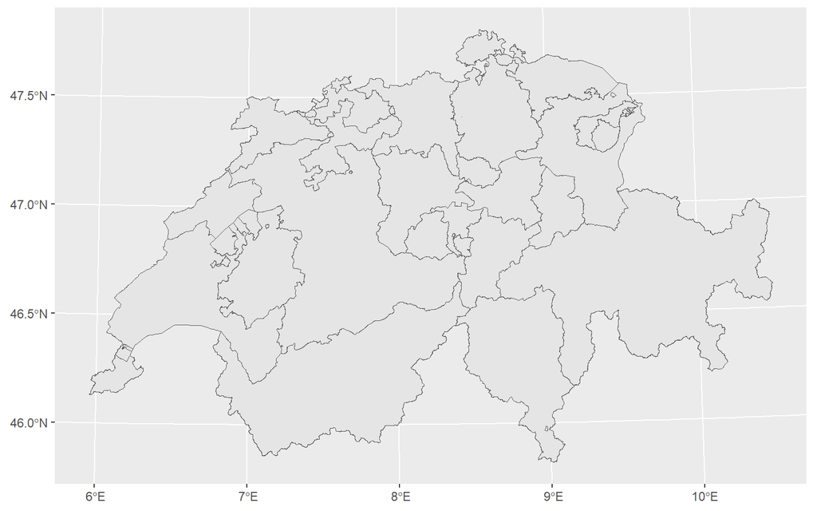

```r
ggplot(shape_cantons) +
  geom_sf()
```

Here we take the simplest case of whether cantons share a border or not, but there are many ways to consider adjacency (Paul Moraga 2024).

```r
shape_cantons_adj = spdep::poly2nb(shape_cantons)
spdep::nb2INLA("data/shape_cantons_adj", shape_cantons_adj)
str(shape_cantons_adj)
```

```
## List of 26
##  $ : int [1:6] 4 5 12 18 25 26
##  $ : int [1:2] 3 16
##  $ : int [1:2] 2 16
##  $ : int [1:11] 1 7 11 12 13 14 15 18 22 23 ...
##  $ : int [1:4] 1 6 11 18
##  $ : int 5
##  $ : int [1:3] 4 13 23
##  $ : int 23
##  $ : int [1:4] 10 16 19 22
##  $ : int [1:4] 9 16 21 22
##  $ : int [1:4] 4 5 13 18
##  $ : int [1:6] 1 4 14 15 19 25
##  $ : int [1:4] 4 7 11 23
##  $ : int [1:5] 4 12 15 19 22
```

[output cut: 17 more lines]

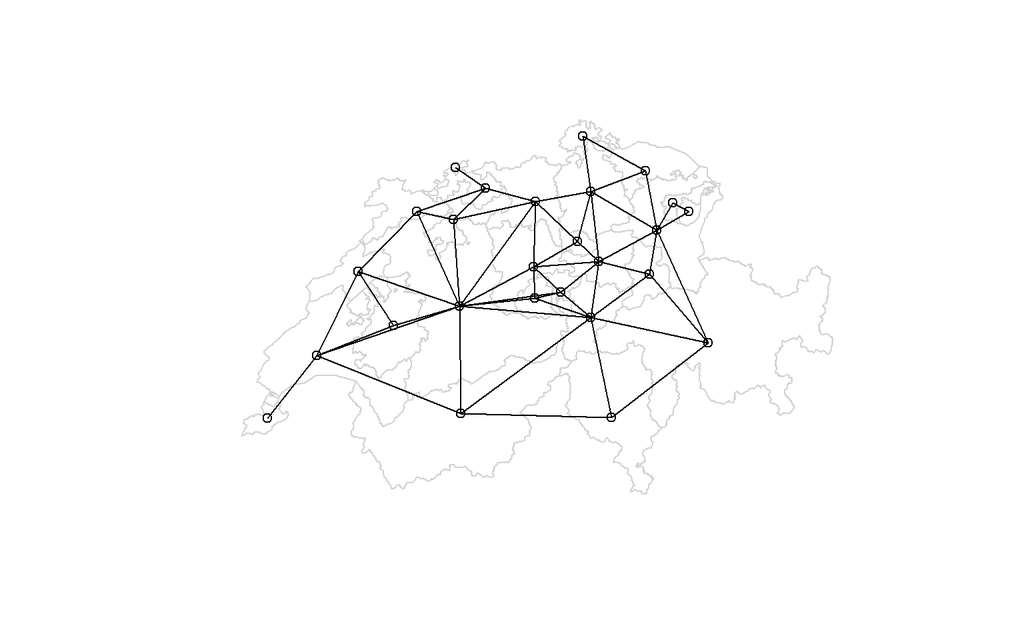

```r
plot(st_geometry(shape_cantons), border = "lightgrey")
plot.nb(shape_cantons_adj, st_geometry(shape_cantons), add = TRUE)
```

There are several spatial models that work with such adjacency matrix, but we will focus on the one by Besag, York and Mollié (**BYM**) (Besag, York, and Mollié 1991). Simply put, the idea is to allow cantons that share a border to be more correlated than cantons that don’t share a border. This is done using a conditional autoregressive model (CAR). The BYM model combines a CAR with an i.i.d random effect, so it can measure how important is the spatial structure provided by the adjacency matrix. This importance is measure by the parameter $\phi$, that can range from 0 (no spatial structure, i.i.d. explains all variation) to 1 (dominant spatial structure, adjacency explains all variation).

```r
prior_bym = list(theta1 = list('PCprior', c(1, 0.01)), theta2 = list('PCprior', c(0.5, 0.5)))
m_canton_ch2 = inla(value ~ 1 +
                           f(canton_id, model="bym2", graph="data/shape_cantons_adj", hyper=prior_bym),
                         offset = log(pop),
                         data=flu_year_ch_canton,
                         family = "poisson",
                         control.fixed = list(mean.intercept=0, prec.intercept=1/10^2),
                         control.compute = list(waic=TRUE))
summary(m_canton_ch2)
```

```
##
## Call:
##    c("inla.core(formula = formula, family = family, contrasts = contrasts,
##    ", " data = data, quantiles = quantiles, E = E, offset = offset, ", "
##    scale = scale, weights = weights, Ntrials = Ntrials, strata = strata,
##    ", " lp.scale = lp.scale, link.covariates = link.covariates, verbose =
##    verbose, ", " lincomb = lincomb, selection = selection, control.compute
##    = control.compute, ", " control.predictor = control.predictor,
##    control.family = control.family, ", " control.inla = control.inla,
##    control.fixed = control.fixed, ", " control.mode = control.mode,
##    control.expert = control.expert, ", " control.hazard = control.hazard,
##    control.lincomb = control.lincomb, ", " control.update =
##    control.update, control.lp.scale = control.lp.scale, ", "
##    control.pardiso = control.pardiso, only.hyperparam = only.hyperparam,
##    ", " inla.call = inla.call, inla.arg = inla.arg, num.threads =
##    num.threads, ", " keep = keep, working.directory = working.directory,
##    silent = silent, ", " inla.mode = inla.mode, safe = FALSE, debug =
##    debug, .parent.frame = .parent.frame)" )
## Time used:
##     Pre = 35.7, Running = 1.35, Post = 0.25, Total = 37.3
## Fixed effects:
##               mean    sd 0.025quant 0.5quant 0.975quant   mode kld
## (Intercept) -6.065 0.046     -6.161   -6.066     -5.968 -6.066   0
##
## Random effects:
##   Name     Model
##     canton_id BYM2 model
##
## Model hyperparameters:
##                          mean    sd 0.025quant 0.5quant 0.975quant  mode
## Precision for canton_id 6.286 1.786      3.422    6.070     10.391 5.677
## Phi for canton_id       0.695 0.192      0.266    0.729      0.965 0.875
##
## Watanabe-Akaike information criterion (WAIC) ...: 250.27
## Effective number of parameters .................: 12.88
##
## Marginal log-Likelihood:  -159.55
##  is computed
## Posterior summaries for the linear predictor and the fitted values are computed
## (Posterior marginals needs also 'control.compute=list(return.marginals.predictor=TRUE)')
```

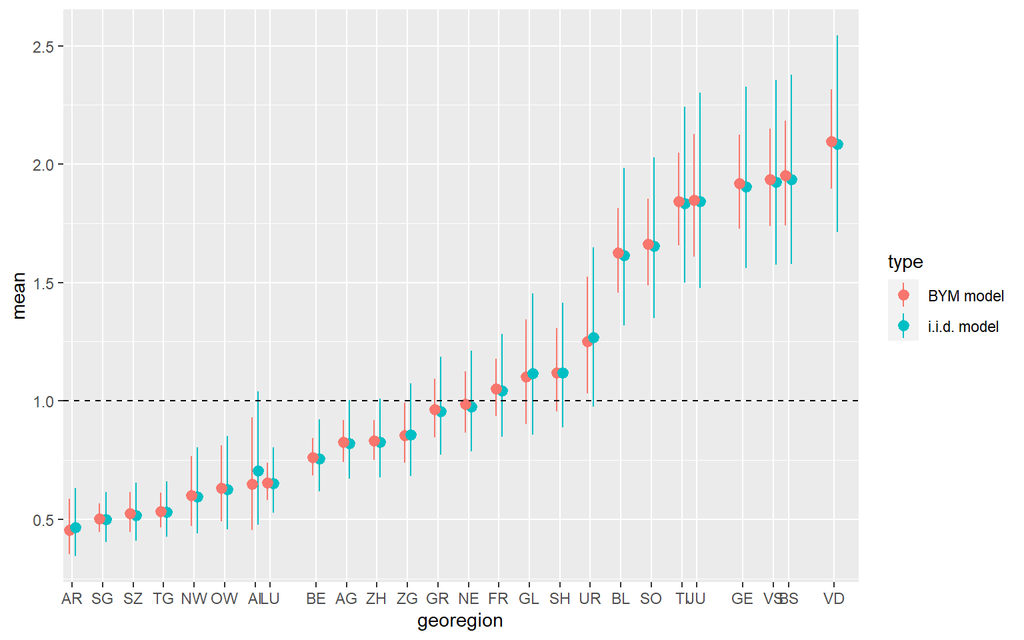

```r
irr = m_canton_ch1$summary.random$canton_id %>%
  select(ID,mean,`0.025quant`,`0.975quant`) %>%
  mutate(across(2:4,exp),
         type="i.i.d. model") %>%
  rename(canton_id=ID) %>%
  left_join(lookup_canton,by = join_by(canton_id))
irr2 = m_canton_ch2$summary.random$canton_id %>%
  select(ID,mean,`0.025quant`,`0.975quant`) %>%
  filter(ID<27) %>%  # there are twice as many random effects as cantons, the second part conrresponds only to the iid part
  mutate(across(2:4,exp), type="BYM model") %>%
  rename(canton_id=ID) %>%
  left_join(lookup_canton,by = join_by(canton_id))
irr_all = bind_rows(irr,irr2) %>%
  arrange(mean)
ggplot(irr_all,aes(x=georegion,y=mean,ymin=`0.025quant`,ymax=`0.975quant`,colour=type)) +
  geom_pointrange(position=position_dodge(.8)) +
  geom_hline(yintercept=1,linetype=2) +
  scale_x_discrete(limits=irr_all$georegion)
```

If we compare the results by canton, expressed as IRRs, we see that the i.i.d. and the BYM models generally agree on the mean estimate, but that the BYM generally has less uncertainty. This is explained by the fact that information is pooled across cantons, which improves the estimate, especially in smaller areas (this issue is known as **small area estimation**). Besides being able to adjust on many different covariates, one of the main advantages of spatial models (compared to just computing differences in total cases between cantons) is this handling of uncertainty and small area estimation.

Just for good measure (because it’s a spatial model) let’s put the IRR estimates on a map.

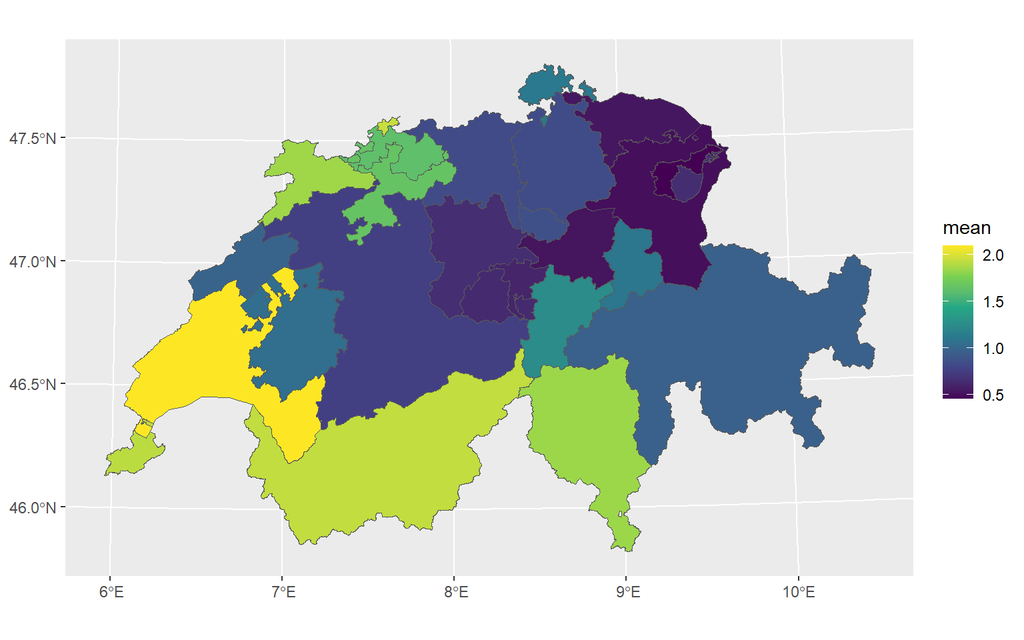

```r
shape_cantons %>%
  left_join(irr2,by = join_by(georegion, canton_id)) %>%
  ggplot() +
  geom_sf(aes(fill=mean)) +
  scale_fill_viridis_c()
```

## 1.1 Exercice

Compare the incidence rate ratios of reported cases of influenza by canton across time.

# References

Besag, Julian, Jeremy York, and Annie Mollié. 1991. “Bayesian Image Restoration, with Two Applications in Spatial Statistics.” *Annals of the Institute of Statistical Mathematics* 43: 1–20.

Paul Moraga. 2024. “Spatial Neighborhood Matrices.” https://www.paulamoraga.com/tutorial-neighborhoodmatrices/.

Simpson, Daniel, Håvard Rue, Andrea Riebler, Thiago G Martins, and Sigrunn H Sørbye. 2017. “Penalising Model Component Complexity: A Principled, Practical Approach to Constructing Priors.”